# Project One: Multiple Regression, Qualitative Variables Interactions, Quadratic Regression

120079.226546824

**210**

-43884.5493387365

**211**

898.992851154127

**212**

-39977.7879583149

**213**

60343.9819856735

**214**

-57244.0797234991

**215**

103725.60971681

**216**

-8491.36583183755

**217**

-75313.9331292194

**218**

87672.40472436

**219**

106646.268096799

**220**

-55864.2246890733

**221**

-74030.3200775288

**222**

-5581.3593808581

**223**

88081.9135452826

**224**

61623.3262447065

**225**

-47041.3423694521

**226**

50030.6056234981

**227**

-41810.7194963408

**228**

-68146.3374716438

**229**

-67087.3366817526

**230**

-4696.33206765854

**231**

-39634.1882140049

**232**

-66801.9255547253

**233**

43332.1043431036

**234**

-102077.861780552

**235**

38820.8315237732

**236**

37677.4479804406

**237**

69672.2209907246

**238**

40663.6985490036

**239**

46344.9130253681

**240**

-58756.5804790124

**241**

-93104.6533704438

**242**

86797.537489952

**243**

151086.372381489

**244**

278.241345462514

**245**

-24410.5414959842

**246**

-46613.3533807234

**247**

86794.1225682965

**248**

-125501.197293879

**249**

23673.7743841645

**250**

42561.8272308451

**251**

209824.182162566

**252**

-98286.4915720597

**253**

35751.7527562905

**254**

145044.488790685

**255**

43175.5444422848

**256**

97828.1813905622

**257**

-101153.179608299

**258**

-5360.97533929156

**259**

-94153.3608298769

**260**

64929.5040273206

**261**

12406.0947492162

**262**

61957.0376781223

**263**

127714.787559268

**264**

-111207.647351261

**265**

-161428.079020016

**266**

96211.0801801523

**267**

165624.310320795

**268**

13845.4366693043

**269**

36838.6171959249

**270**

131755.992867165

**271**

140807.340638621

**272**

117792.102859469

**273**

-68367.7582819797

**274**

12935.7897108529

**275**

-51971.0471114308

**276**

60760.6063575633

**277**

9408.06602861297

**278**

103914.774236033

**279**

9585.73809987532

**280**

-78743.0672751528

**281**

52821.8710049997

**282**

65223.1633798001

**283**

89431.2851443364

**284**

-243024.382940118

**285**

-162007.095235324

**286**

-70687.9725327332

**287**

-54906.2620203946

**288**

62083.7968515282

**289**

-12889.8927771313

**290**

-13288.768288491

**291**

14384.1556518062

**292**

34499.5281939015

**293**

-70149.4212821623

**294**

111737.518331903

**295**

-25526.9743316818

**296**

-112931.932572316

**297**

148724.794457958

**298**

94213.0282006452

**299**

18028.0679609557

**300**

40893.0037427503

**301**

47310.9798959702

**302**

54914.2381837106

**303**

122863.164596893

**304**

72940.1878118099

**305**

-36413.4750696962

**306**

-25938.8329781124

**307**

107735.022630183

**308**

-57107.9222886942

**309**

-19250.0954868387

**310**

-95262.4931467199

**311**

-25721.1047050007

**312**

243487.735151134

**313**

73623.6422886986

**314**

-86393.1073172671

**315**

132842.742990907

**316**

14033.9910724162

**317**

59282.482093025

**318**

175026.569515249

**319**

44908.1219283969

**320**

-62765.2221462555

**321**

20458.074762128

**322**

-14198.1728056356

**323**

62879.3640510356

**324**

25383.3909436741

**325**

3486.84853532481

**326**

-49151.6876707849

**327**

-1471.48228654921

**328**

-69947.1006643453

**329**

-28992.0278111114

**330**

-48582.3406036984

**331**

-69475.548200362

**332**

-46407.3381759903

**333**

62795.9682848046

**334**

-62584.0440327492

**335**

104714.516661411

**336**

141653.778444731

**337**

-14284.7444323109

**338**

40676.7452508251

**339**

-118355.065622893

**340**

60060.6243622812

**341**

-61326.9366796298

**342**

-58943.5687247994

**343**

-37524.2178166637

**344**

152790.073198509

**345**

42118.5766538326

**346**

-12336.5962040593

**347**

58628.2852327856

**348**

-82759.3910543063

**349**

56033.3124988182

**350**

121414.015999438

**351**

71733.9261167361

**352**

-10082.9468716704

**353**

77212.8646364034

**354**

-88878.3643231429

**355**

-74996.613660591

**356**

-3737.0112804248

**357**

-80955.5126654726

**358**

22185.4681108215

**359**

103372.242259422

**360**

-143697.369339523

**361**

-63467.6197833793

**362**

107282.8834932

**363**

70341.9430304599

**364**

13729.9101290393

**365**

-6946.27322403658

**366**

-58843.0642600684

**367**

123718.786431732

**368**

-88275.9706115172

**369**

48178.6043170444

**370**

-15182.3245560486

**371**

-4892.08504582036

**372**

-96922.6973225141

**373**

173684.043188191

**374**

57694.4553646803

**375**

111584.878836852

**376**

-36477.9496281393

**377**

-30187.8239404399

**378**

81330.8243565932

**379**

-57671.9509967886

**380**

-14523.7626676298

**381**

-124897.415639604

**382**

14046.8674445648

**383**

73918.4765157599

**384**

131779.349961801

**385**

28489.4985085267

**386**

49113.8716347076

**387**

18935.1048956455

**388**

-80045.0400803821

**389**

30681.5176348138

**390**

47626.9868489209

**391**

-122987.506932032

**392**

-11216.3942250555

**393**

-133565.323151666

**394**

-69921.5263074957

**395**

-9284.57319284176

**396**

40924.9523604499

**397**

-55463.2611457053

**398**

-112420.392454304

**399**

159000.064843028

**400**

80335.0090000357

**401**

66321.069766308

**402**

-67423.3097158858

**403**

162799.809729033

**404**

37086.2758004285

**405**

117840.481267032

**406**

-66815.2641616527

**407**

-136091.326091617

**408**

25850.2715929877

**409**

-43295.8681015061

**410**

2973.50658605496

**411**

50658.530766392

**412**

165805.977979326

**413**

-84627.9187606169

**414**

-103462.258552328

**415**

22815.5924280138

**416**

-118801.086465454

**417**

-93477.172383498

**418**

-68783.235079978

**419**

-76731.2221452533

**420**

21225.6947771184

**421**

170464.869475188

**422**

-26633.9080424354

**423**

-86631.6742277203

**424**

23578.2524036989

**425**

43902.0604177383

**426**

32773.0146643514

**427**

-209812.580214022

**428**

-28947.3960979248

**429**

-118608.666046798

**430**

-158894.59393459

**431**

341170.386844391

**432**

-35915.6730568168

**433**

44875.9401152325

**434**

-25365.2331309887

**435**

-221690.874585472

**436**

225927.353289333

**437**

-58928.1848903082

**438**

41265.8900661919

**439**

-41493.9682518628

**440**

28441.1440059911

**441**

-69136.7661563044

**442**

-33239.9246561874

**443**

102563.370424336

**444**

-48253.3583743669

**445**

-114335.448710892

**446**

-86002.4079048968

**447**

-20214.6964428303

**448**

74967.7660045127

**449**

62969.8327395074

**450**

-10473.1306861667

**451**

-118470.569937795

**452**

-98962.5005245658

**453**

47970.5077347462

**454**

107598.211985612

**455**

-25724.1123158253

**456**

227452.677120782

**457**

144524.567036732

**458**

-146322.232930503

**459**

-91789.5316997966

**460**

16050.1772572816

**461**

-49584.8921524892

**462**

230282.276246391

**463**

16999.899820541

**464**

-12903.5346622634

**465**

34626.3877081925

**466**

-58070.4959726794

**467**

-69551.3203189798

**468**

1933.08717165298

**469**

75109.4798056989

**470**

28065.6404584791

**471**

297441.040581905

**472**

-92257.6200885014

**473**

36535.226523636

**474**

-38791.1579789532

**475**

-57730.3781632234

**476**

-41676.4328045045

**477**

64698.5388193318

**478**

86654.8428918251

**479**

-63847.4366258015

**480**

119122.566468742

**481**

237864.529145334

**482**

-77747.5610478791

**483**

-16096.3836913871

**484**

-14.8275072866539

**485**

136056.605505464

**486**

-87521.5676423063

**487**

-22795.0395187174

**488**

27545.7669007245

**489**

-49185.4581097281

**490**

41977.9838660939

**491**

-214004.375335292

**492**

165781.503203019

**493**

114693.8291909

**494**

-45209.9358249443

**495**

-110057.522865949

**496**

-89994.4938879949

**497**

-27216.3297036586

**498**

148206.09095504

**499**

13476.4960793169

**500**

-182237.154184414

**501**

-174391.496577776

**502**

-94123.1443253666

**503**

-55992.6023947602

**504**

50760.9423473987

**505**

-142154.257529693

**506**

-28117.8041387884

**507**

-68685.593505783

**508**

123279.833142645

**509**

51783.6269154449

**510**

-88401.1006655094

**511**

62650.4700007837

**512**

-16093.8307565125

**513**

-39569.8070549552

**514**

3293.73385923198

**515**

-67423.4861494575

**516**

152349.966979857

**517**

-51384.0058863364

**518**

-49940.5479209958

**519**

-17620.2784798237

**520**

19309.0266323692

**521**

63419.8177058593

**522**

33808.5059327988

**523**

89290.2878195886

**524**

59358.6865554233

**525**

-1458.38706562928

**526**

-72999.0185816183

**527**

-28723.123291625

**528**

28333.1047719826

**529**

71014.0610126161

**530**

-38698.7064198181

**531**

-29585.2208739304

**532**

-15787.9000480234

**533**

194864.627910267

**534**

-137596.141106648

**535**

105506.039245947

**536**

47909.86637793

**537**

-75775.8488163342

**538**

-98169.7967308616

**539**

-99179.9066528395

**540**

-100004.839339568

**541**

54091.1732269301

**542**

-25675.5036253448

**543**

-65222.2973694102

**544**

-6651.70261918762

**545**

11666.704851994

**546**

-11491.7698598542

**547**

63939.3760698539

**548**

-93682.2314599785

**549**

373126.683055549

**550**

-54674.2610101704

**551**

-36896.5266933197

**552**

52188.8410864247

**553**

-25789.3254232856

**554**

-102052.441485969

**555**

8498.21987810987

**556**

-148284.272162229

**557**

-69557.7288482773

**558**

-49406.2556583296

**559**

90599.8189241807

**560**

-9602.65371547356

**561**

-74595.2633009632

**562**

155512.16348633

**563**

88408.9314883322

**564**

128894.495349414

**565**

70426.7014724203

**566**

77152.3410100971

**567**

-40918.4160670586

**568**

-59889.9663705254

**569**

-73176.3564168071

**570**

32796.377315884

**571**

-19054.8406138093

**572**

-101791.841955662

**573**

87891.2917947901

**574**

-12108.6545489996

**575**

13210.0010514227

**576**

-86817.3328299233

**577**

152355.345243906

**578**

64654.7318517372

**579**

34972.350258132

**580**

-50811.3853173174

**581**

-161461.579459809

**582**

49083.510061045

**583**

-173831.959311608

**584**

29986.5333748863

**585**

61785.3851759523

**586**

-58406.4771309138

**587**

-115389.417280597

**588**

8269.66626832301

**589**

-76518.9488346235

**590**

76088.5661334018

**591**

-141226.572889771

**592**

-49415.7286602851

**593**

-186596.141106648

**594**

-54985.0053552103

**595**

-162097.07319902

**596**

83071.8564119794

**597**

-117615.890451295

**598**

-53833.8481571378

**599**

-155663.26693311

**600**

-60147.713206819

**601**

-11261.1146438632

**602**

124248.564425061

**603**

34008.4957063021

**604**

-14179.3930160292

**605**

43242.0858020056

**606**

16960.5214673654

**607**

61171.4451308145

**608**

39716.3610584948

**609**

116210.316904508

**610**

146447.138701968

**611**

30787.162997016

**612**

-74856.3386873846

**613**

-25595.4018557757

**614**

-65029.4232720974

**615**

-61626.4596752765

**616**

-108370.949429973

**617**

-21830.1043943909

**618**

-75149.4120681206

**619**

50330.6877697634

**620**

-47263.3251761251

**621**

-89950.7477419995

**622**

53673.8991475061

**623**

76865.092620835

**624**

18260.4940474137

**625**

61144.4993572623

**626**

1415.8677827981

**627**

21348.3415640525

**628**

103271.556400115

**629**

37344.1670562457

**630**

155463.376684274

**631**

26468.6530338598

**632**

21677.8658031812

**633**

20740.5994174472

**634**

91567.2683003062

**635**

31925.2815652174

**636**

-33610.6813886423

**637**

63377.8447051213

**638**

19997.7248232076

**639**

139801.283329532

**640**

148856.245085715

**641**

-44239.0576526013

**642**

38965.3403507928

**643**

-19196.6354638099

**644**

-90789.8076243822

**645**

-169039.299654263

**646**

145160.725916144

**647**

-17127.0039343642

**648**

6030.44119391305

**649**

78661.3113353924

**650**

-48452.0280806722

**651**

-36533.4440258769

**652**

112133.429140297

**653**

-91943.0731415434

**654**

71851.0346108218

**655**

-130267.027811111

**656**

56520.8108763318

**657**

-12759.3953564104

**658**

24165.8874849919

**659**

64555.0992652217

**660**

148879.29982802

**661**

15777.1344320751

**662**

-12428.708461996

**663**

-43682.6001882454

**664**

-149201.475908788

**665**

-76320.5524533628

**666**

-49917.1281159894

**667**

29024.4909383278

**668**

81314.9796184669

**669**

31971.4474175813

**670**

-162063.843078089

**671**

10129.4148356143

**672**

-9334.00732370444

**673**

174650.204878416

**674**

98932.7387984629

**675**

-220745.341275914

**676**

-104433.771092936

**677**

-110345.547769719

**678**

62479.9197097121

**679**

29394.0535422049

**680**

-45478.5605977985

**681**

-23776.8366201999

**682**

80635.1452942392

**683**

-187333.048210595

**684**

-149660.143165067

**685**

153930.334848381

**686**

61786.5154829539

**687**

-23533.4537332278

**688**

-187835.011230597

**689**

-21968.7785537182

**690**

87081.2953387951

**691**

-33439.0860877452

**692**

111836.687134735

**693**

-94058.8182467699

**694**

54481.669811774

**695**

-203940.413232984

**696**

-59422.9047230655

**697**

-67468.5673678192

**698**

-113925.742054628

**699**

18838.9686642976

**700**

-67305.203629019

**701**

127861.996633207

**702**

11485.1495814994

**703**

15343.7685409104

**704**

41244.4243208808

**705**

-35583.9656626926

**706**

-88727.3345006134

**707**

-19670.8255767968

**708**

-139442.60126525

**709**

-75431.7821074562

**710**

-71224.985333155

**711**

9842.96740604432

**712**

-10114.8819465204

**713**

-107401.660008408

**714**

-57030.0341519473

**715**

32691.7367710226

**716**

367.713208807093

**717**

-62569.5143895041

**718**

241244.45849539

**719**

-78084.6833462977

**720**

25441.1815739707

**721**

-106911.374229715

**722**

-71588.1877294791

**723**

-89113.0548201454

**724**

109817.675443951

**725**

-13984.4905253819

**726**

-90233.8100995742

**727**

-20531.0550804572

**728**

66998.5812494488

**729**

-166766.819545086

**730**

171131.010157566

**731**

-108192.426502009

**732**

96832.2710603395

**733**

105505.678636585

**734**

-46143.5300089683

**735**

-99864.299850284

**736**

-58865.13478357

**737**

-70593.0010026106

**738**

117417.660967686

**739**

-135017.774467725

**740**

97518.904432765

**741**

-90455.2329032533

**742**

58124.4134533039

**743**

-35932.9634514543

**744**

-204615.883419025

**745**

66841.8649052589

**746**

82404.7366990368

**747**

-284.522125660677

**748**

-66854.77736537

**749**

-64682.9364852065

**750**

119180.051994054

**751**

-56227.5153714567

**752**

-47968.4765165262

**753**

27005.8470886542

**754**

124555.048289867

**755**

-2555.84400677113

**756**

-112611.784970671

**757**

-53541.0242736483

**758**

-2567.78908160001

**759**

101566.290530335

**760**

203163.723684603

**761**

19944.5753847927

**762**

-141136.089482241

**763**

62742.6314660003

**764**

38568.7310210569

**765**

-94576.0147732612

**766**

253072.252278767

**767**

83911.8513228465

**768**

61980.6730387772

**769**

-118375.495331593

**770**

232769.387163078

**771**

-38842.949781342

**772**

200208.321079889

**773**

12708.693885708

**774**

50983.8429885296

**775**

-43376.2910029818

**776**

10182.7482589229

**777**

-369.855962508596

**778**

-92813.6045157777

**779**

-72936.7929783659

**780**

-1777.56618158791

**781**

30001.0218526921

**782**

-21992.7341551847

**783**

-163212.735495783

**784**

46571.8714489854

**785**

-151605.592685762

**786**

27108.7473215615

**787**

-53227.3628622132

**788**

38069.536353027

**789**

223543.989993165

**790**

57701.3532686068

**791**

-101971.574901376

**792**

-70436.067531766

**793**

63167.7332952799

**794**

-89720.0575594285

**795**

32937.0445201942

**796**

-15388.9950187495

**797**

26020.5606053135

**798**

-77695.8977544855

**799**

40622.8266999259

**800**

-54875.9347647095

**801**

59346.2954805305

**802**

-134464.536656281

**803**

201934.478645256

**804**

-34838.3195986039

**805**

-92801.8593769532

**806**

-90545.3402337294

**807**

14545.309310599

**808**

-83714.8948278933

**809**

-136377.165570843

**810**

-47320.1439739497

**811**

24507.5684793057

**812**

16459.9090715649

**813**

180864.926752262

**814**

8506.20976332622

**815**

-15098.9187982155

**816**

5528.51101192585

**817**

133290.149143626

**818**

326007.231633368

**819**

16190.6825754878

**820**

14803.4360838705

**821**

-114957.608955898

**822**

-54191.4528896985

**823**

-81894.3969183892

**824**

105806.072271236

**825**

86337.2886981539

**826**

67281.3013231343

**827**

-61705.0203654661

**828**

-242230.978500065

**829**

26186.8514043292

**830**

-51849.1194720207

**831**

14208.9412421409

**832**

-140544.285266164

**833**

-49491.7316976611

**834**

79499.4188352379

**835**

137175.323192962

**836**

-63203.3938835695

**837**

96438.3914245801

**838**

-72863.4823360846

**839**

-89121.1290155838

**840**

-131142.870487675

**841**

-122612.659368861

**842**

-45175.8792066929

**843**

9118.82740511575

**844**

25531.880095445

**845**

71991.0157871809

**846**

-19356.286141457

**847**

53127.024419127

**848**

-20322.3253755753

**849**

252725.425222812

**850**

200835.00503756

**851**

54510.652228634

**852**

15141.924005853

**853**

-50880.0198556942

**854**

-201727.511529323

**855**

-14893.8849596259

**856**

-159374.407325684

**857**

34057.0496491518

**858**

74624.2343912293

**859**

61936.0110086882

**860**

191081.817873986

**861**

111895.524754492

**862**

23284.8105997119

**863**

-8527.33450061339

**864**

-5685.08828652325

**865**

-24242.9981534008

**866**

123630.263378429

**867**

-110091.634315386

**868**

-2929.5799262315

**869**

120966.924782354

**870**

64116.1781130078

**871**

-36340.879955008

**872**

-133848.634995678

**873**

-14700.9794606253

**874**

188628.833781834

**875**

12263.9953590351

**876**

-42539.0279403373

**877**

-171112.476586508

**878**

17947.6198889712

**879**

32590.7134000133

**880**

107476.786591615

**881**

23294.0105075597

**882**

47586.556137382

**883**

70519.0537202114

**884**

-17277.4345179585

**885**

-14901.9623765044

**886**

-139928.643773405

**887**

-156251.356713794

**888**

-22394.5143726075

**889**

164683.15560382

**890**

67070.6605763748

**891**

134791.638132643

**892**

-68415.8986494665

**893**

58936.3556077601

**894**

-319378.012652541

**895**

87321.916530344

**896**

-57099.3140809202

**897**

-115302.866470233

**898**

9080.18774412166

**899**

-109648.961948746

**900**

-28335.3586041709

**901**

121543.304369611

**902**

213656.001027562

**903**

-39642.8479167656

**904**

4385.34939033724

**905**

-43350.8527775263

**906**

-20790.7583655081

**907**

-100272.457800982

**908**

84187.577260703

**909**

179397.47407843

**910**

41918.6406191419

**911**

-46655.1338145876

**912**

-32872.2377826504

**913**

-124736.578065124

**914**

94200.9237183293

**915**

-26661.4679651855

**916**

120628.524809684

**917**

-132628.170133675

**918**

107098.889218906

**919**

-55231.8339148895

**920**

126093.378153194

**921**

-95220.0568879885

**922**

-124065.627572949

**923**

-158109.618442312

**924**

-57843.4536318155

**925**

20137.2113272858

**926**

12224.6937525431

**927**

-104826.290170933

**928**

-52929.9066327604

**929**

1075.36091701513

**930**

159309.645506838

**931**

54661.0323657392

**932**

88924.8167565869

**933**

-121697.369339523

**934**

-57861.7298355142

**935**

-92643.5300089683

**936**

19614.0489140509

**937**

-110940.143575166

**938**

73592.1991856189

**939**

-185519.907128739

**940**

-104037.464179685

**941**

79001.5952682038

**942**

205007.569149143

**943**

5220.4524725896

**944**

150998.739480056

**945**

39416.1391336439

**946**

26977.7243476856

**947**

-5393.10842014727

**948**

104582.11831305

**949**

28931.1506215504

**950**

140299.379434707

**951**

-30557.2917063088

**952**

218027.835686978

**953**

69713.4985074073

**954**

64087.8459536545

**955**

132123.076969735

**956**

-35098.8808665116

**957**

-63038.8407091768

**958**

104747.356679241

**959**

-25256.9057893591

**960**

41857.1169018171

**961**

85624.7922113068

**962**

28119.8511629183

**963**

-36164.3191252268

**964**

-45058.9593969218

**965**

-7124.44612552835

**966**

20133.3219560921

**967**

247195.697813404

**968**

69375.4161900786

**969**

41088.4275317811

**970**

-125338.814373854

**971**

36176.6670597803

**972**

20177.810559245

**973**

-120876.451186906

**974**

18899.9778188686

**975**

-77113.0575103304

**976**

146965.461141077

**977**

-65468.4798272668

**978**

28886.6817905251

**979**

13958.2935685813

**980**

118888.429524395

**981**

-65983.5228310069

**982**

-41427.181105878

**983**

121962.752546302

**984**

-90825.3114064707

**985**

120786.472706262

**986**

-24029.403180758

**987**

33494.1205570435

**988**

-97312.5802140225

**989**

-2194.03070632208

**990**

-71673.7111973667

**991**

-133207.175669722

**992**

-48747.2426798202

**993**

-71187.3856272585

**994**

-18202.8617724851

**995**

-32917.2860165544

**996**

-94733.8659829338

**997**

52844.5643444468

**1003**

-108079.271583461

**1004**

-131598.528078137

**1005**

-26717.0414449921

**1006**

-7008.2788540106

**1007**

-27110.9525636679

**1008**

-12303.3705430378

**1009**

-183605.793959977

**1010**

-28061.912117599

**1011**

-35231.8339148895

**1012**

-113329.783855393

**1013**

-138536.028733918

**1014**

-16253.9240088157

**1015**

88523.0782942476

**1016**

-36902.1676343589

**1017**

-74047.0721156938

**1018**

-30272.3590256535

**1019**

-110808.054569337

**1020**

-159124.612835095

**1021**

-6229.95203061159

**1022**

-68114.9440765715

**1023**

-46730.431300239

**1024**

148888.756182515

**1025**

46801.9611557321

**1026**

25155.8929013588

**1027**

192976.696889042

**1028**

-58153.6272684442

**1029**

-154407.848963389

**1030**

-127106.261922369

**1031**

-33537.8248132698

**1032**

103207.36583779

**1033**

-83167.5705793507

**1034**

-10793.9754680559

**1035**

107059.478977131

**1036**

-46289.4749863075

**1037**

-111896.135667684

**1038**

-27433.7504871131

**1039**

-168952.29869408

**1040**

-140668.582509245

**1041**

-75177.4925950519

**1042**

16582.4805470512

**1043**

165574.216025475

**1044**

-17828.8567511147

**1045**

-107675.232529789

**1046**

44318.2577910489

**1047**

115431.871265971

**1048**

119294.474367831

**1049**

41258.3392877751

**1050**

74417.0227503554

**1051**

78526.1333049472

**1052**

-81339.689658042

**1053**

-175282.737786458

**1054**

126241.584330769

**1055**

7873.5228836657

**1056**

-74025.057054761

**1057**

59290.0702472023

**1058**

315072.362286757

**1059**

-998.672313938989

**1060**

-44581.1159793066

**1061**

-29862.6291268328

**1062**

87122.5755737032

**1063**

-63389.7834721227

**1064**

4410.01458376631

**1065**

-8161.48551649677

**1066**

-122582.005890685

**1067**

-14517.2240432994

**1068**

2008.28549832654

**1069**

-209497.965062163

**1070**

63218.9164754488

**1071**

-44539.8628006116

**1072**

6131.3566307067

**1073**

-40905.2865028889

**1074**

176716.678766453

**1075**

72752.3714966827

**1076**

87004.0031007341

**1077**

-144782.917594372

**1078**

47141.6175250291

**1079**

82869.4802832311

**1080**

72124.4892970357

**1081**

-7801.70394396233

**1082**

-179435.431950686

**1083**

-110231.606370657

**1084**

118847.432713661

**1085**

-36200.6081159185

**1086**

148917.416938989

**1087**

6820.45332504755

**1088**

-10335.3547314662

**1089**

-26895.7085002867

**1090**

20471.5080037559

**1091**

-5149.66759503146

**1092**

-2032.14885502192

**1093**

-9639.59954009734

**1094**

10360.4004599027

**1095**

60660.1781764183

**1096**

-111170.692722009

**1097**

-8825.94463119945

**1098**

-35562.3511086521

**1099**

133883.162797664

**1100**

10291.8436436228

**1101**

-109647.077263647

**1102**

170872.620070852

**1103**

-59507.7061547309

**1104**

-30419.773393139

**1105**

17636.8024024343

**1106**

-25005.1300484144

**1107**

-18674.3624131411

**1108**

-36881.840500692

**1109**

-10550.6446584163

**1110**

47467.1736176733

**1111**

-140140.889116293

**1112**

158495.743415423

**1113**

-16721.6615722367

**1114**

83367.7451361327

**1115**

-93716.4161964358

**1116**

-123842.300860024

**1117**

70846.1792451663

**1118**

-101319.460346241

**1119**

198272.99109375

**1120**

-98654.4744210909

**1121**

91052.1007818132

**1122**

174056.07776711

**1123**

120654.625522801

**1124**

-1060.87330783315

**1125**

-57152.9073939169

**1126**

-75855.265857457

**1127**

-74471.455028988

**1128**

42758.0769581763

**1129**

-105628.640870678

**1130**

113332.944334608

**1131**

-76210.5677378562

**1132**

142685.329214168

**1133**

2650.71438956422

**1134**

219304.595523746

**1135**

-41275.0212963388

**1136**

179578.071422667

**1137**

-40773.4384627934

**1138**

-119192.504400796

**1139**

-54575.0889914103

**1140**

42169.7436159862

**1141**

2083.7747292821

**1142**

-79531.7327409817

**1143**

-5250.54654235631

**1144**

-102245.608157997

**1145**

-11766.2125870447

**1146**

-13108.0249941494

**1147**

-94500.7908028326

**1148**

41089.3609569572

**1149**

12332.0505374277

**1150**

-39990.5486021049

**1151**

78341.9539223112

**1152**

-104396.349471735

**1153**

-108910.328036074

**1154**

-23903.220476409

**1155**

-128597.131260093

**1156**

8091.82563093293

**1157**

-59491.1271330035

**1158**

14123.876934562

**1159**

-20426.4898494275

**1160**

40770.9662603664

**1161**

-136913.840646133

**1162**

168637.840409737

**1163**

259465.690123653

**1164**

45981.2429161854

**1165**

183499.87459334

**1166**

-51048.5750006703

**1167**

-16791.6980701063

**1168**

105113.155259188

**1169**

-15254.9754385723

**1170**

2455.19154131298

**1171**

-49374.4849156933

**1172**

-15901.3736836714

**1173**

128804.986336158

**1174**

110608.446175605

**1175**

-11994.5372569355

**1176**

-44293.4090264451

**1177**

-80243.16790654

**1178**

57424.3600763605

**1179**

74991.7417541156

**1180**

75250.8086233138

**1181**

-120528.059850903

**1182**

-43278.8310227993

**1183**

-75795.0951699618

**1184**

95926.2791053272

**1185**

126000.737939122

**1186**

-82097.0731990204

**1187**

101314.766174168

**1188**

-85894.1116873234

**1189**

-92932.1493252147

**1190**

135517.153860853

**1191**

51831.1352706086

**1192**

20621.6095925554

**1193**

-54824.583954281

**1194**

-24746.5426354517

**1195**

49586.7821518629

**1196**

132982.553510429

**1197**

86409.0962388139

**1198**

-37874.0450650719

**1199**

22231.3237097092

**1200**

106107.038124992

**1201**

-45200.9918818357

**1202**

-24230.3145023427

**1203**

-109977.048280749

**1204**

37725.8318781297

**1205**

11116.1201767944

**1206**

5790.32200597028

**1207**

17797.9727400145

**1208**

-122062.899260347

**1209**

129572.859823127

**1210**

-17981.4219411811

**1211**

94198.5252107368

**1212**

84974.5307791644

**1213**

-19339.8218235817

**1214**

4725.38815596549

**1215**

129982.092769724

**1216**

-41715.672766223

**1217**

-68384.8465279322

**1218**

24046.0867239018

**1219**

252488.6510416

**1220**

-3339.8807031511

**1221**

-44449.3488148297

**1222**

64.5101807307852

**1223**

-29763.0720911861

**1224**

-35064.3382268886

**1225**

-76855.6201167055

**1226**

-77328.354772171

**1227**

85237.1981364861

**1228**

248282.219405211

**1229**

31619.0180875982

**1230**

-147530.165941298

**1231**

32399.8110169052

**1232**

-12660.6138084361

**1233**

-183262.13893521

**1234**

-102999.494931469

**1235**

136668.896796844

**1236**

-240191.314972777

**1237**

-56677.4235478934

**1238**

26261.936639892

**1239**

45297.0575511101

**1240**

38260.4962093367

**1241**

-2671.80197544113

**1242**

-132420.096834069

**1243**

-71036.4788338379

**1244**

-21400.6350327351

**1245**

109040.56035469

**1246**

-68419.8895976726

**1247**

-20773.9382349488

**1248**

72223.4233944306

**1249**

21975.4396037419

**1250**

-79474.7895393733

**1251**

-57393.9496306412

**1252**

26235.5985708049

**1253**

119491.145967983

**1254**

41044.9884910353

**1255**

-2555.00598937068

**1256**

53732.5211003015

**1257**

-85792.597775675

**1258**

-23704.0539189399

**1259**

139814.109516613

**1260**

22957.3233185277

**1261**

-22815.4322735349

**1262**

-8007.41895438959

**1263**

39111.4444751896

**1264**

32580.2954758781

**1265**

-47495.624737602

**1266**

-4086.4311389171

**1267**

-8070.27341547918

**1268**

-54106.0855286978

**1269**

4484.41389340263

**1270**

-66362.8105602009

**1271**

-88534.1322172019

**1272**

26709.3977532514

**1273**

223712.227404662

**1274**

222460.315966758

**1275**

86098.08284807

**1276**

-22497.9818852611

**1277**

6910.26647945178

**1278**

-104267.882996892

**1279**

-7292.47827993754

**1280**

48059.2440927406

**1281**

-35832.6236588183

**1282**

136154.392428626

**1283**

101300.04830192

**1284**

-14784.1196302566

**1285**

-14917.053836606

**1286**

-22798.5762938074

**1287**

-101543.895808271

**1288**

-89663.5178935726

**1289**

2621.4880846828

**1290**

69385.5743225467

**1291**

-29246.76308913

**1292**

147755.565059106

**1293**

97384.4384622011

**1294**

-94128.1716272433

**1295**

-3735.32726588647

**1296**

-34557.1751800951

**1297**

-46332.2789136091

**1298**

67964.5744590556

**1299**

-75801.4747892632

**1300**

44607.1477188092

**1301**

-42380.9824024285

**1302**

-63087.3430950423

**1303**

57170.3983041355

**1304**

-201590.506965825

**1305**

-11867.3120861559

**1306**

-36272.6414869829

**1307**

135720.093339628

**1308**

47575.596819242

**1309**

6773.8257930271

**1310**

-84939.4617399621

**1311**

36391.8010592047

**1312**

-19249.5687165513

**1313**

118842.032311771

**1314**

-66905.1979523304

**1315**

-37495.5254264192

**1316**

190697.236800032

**1317**

-26339.5143501783

**1318**

-14614.2524141797

**1319**

-114481.978664335

**1320**

28985.0896236929

**1321**

-71298.9966283106

**1322**

-53293.116613745

**1323**

-76933.163651528

**1324**

-69877.7728147094

**1325**

-14297.8195445

**1326**

25961.692352243

**1327**

58699.326706938

**1328**

6655.29378768261

**1329**

16374.9110085897

**1330**

87384.1930494341

**1331**

20061.4097717166

**1332**

36775.8039622067

**1333**

7250.50788883881

**1334**

-43036.0077979101

**1335**

-96741.1824594783

**1336**

211885.274164806

**1337**

25395.4625384859

**1338**

-76934.7822235869

**1339**

-13667.2893583785

**1340**

-17691.3003609259

**1341**

124042.380643135

**1342**

-117982.110317801

**1343**

119683.508876774

**1344**

48704.4112208681

**1345**

-11740.7342392917

**1346**

74001.9600404872

**1347**

-88354.4202338655

**1348**

39063.1846320733

**1349**

8279.3278955332

**1350**

-200346.061495683

**1351**

-154068.782179733

**1352**

-588.089519613816

**1353**

77657.3715629525

**1354**

101871.000808757

**1355**

-58512.6019663343

**1356**

-103304.805151505

**1357**

205797.025363052

**1358**

-99473.5547277067

**1359**

59593.2414220061

**1360**

-38760.2393902813

**1361**

101845.983855716

**1362**

-95217.3386387356

**1363**

-112403.713633497

**1364**

-119699.442938874

**1365**

-27783.4576129631

**1366**

195684.545946074

**1367**

8871.52171483081

**1368**

29647.9926252182

**1369**

224109.860031913

**1370**

-39312.9462442359

**1371**

-58822.7752428749

**1372**

-21908.6444504894

**1373**

-53902.8521239726

**1374**

-36027.8980970541

**1375**

-43925.7906387893

**1376**

50537.2315260295

**1377**

178019.142417319

**1378**

179292.523329808

**1379**

-56047.6687746055

**1380**

37684.5570841561

**1381**

44360.6864654889

**1382**

52001.6650610513

**1383**

98995.6246647084

**1384**

-151881.742964267

**1385**

-22095.1170303715

**1386**

117947.493142093

**1387**

42108.2712470586

**1388**

-108577.080212874

**1389**

13573.8794447242

**1390**

4180.33933282962

**1391**

114689.265815369

**1392**

120811.602924465

**1393**

-153538.620684722

**1394**

172089.415610789

**1395**

-123974.080179553

**1396**

21911.394423699

**1397**

-205837.549381055

**1398**

366429.429051365

**1399**

-173723.666997989

**1400**

-22482.4219374003

**1401**

264938.444726049

**1402**

129513.136788736

**1403**

-31060.1125143101

**1404**

169689.306524073

**1405**

175971.901844794

**1406**

10024.481930617

**1407**

89636.9086011011

**1408**

-140984.981928619

**1409**

91115.0592190257

**1410**

-143742.595731318

**1411**

-25204.6221277271

**1412**

42078.1149564379

**1413**

-100854.589860445

**1414**

155586.080507513

**1415**

165483.327839031

**1416**

-43486.6296229905

**1417**

-49125.7599895722

**1418**

27082.2028343431

**1419**

152638.679851198

**1420**

146346.117709373

**1421**

5420.55524942419

**1422**

-56171.083644261

**1423**

93985.6534639063

**1424**

-114714.613037654

**1425**

108376.045908656

**1426**

-94464.7968114989

**1427**

143678.032612415

**1428**

301285.855848908

**1429**

-64035.144288766

**1430**

-27208.5536399942

**1431**

48139.8177479366

**1432**

-51595.9684735108

**1433**

-107208.163461567

**1434**

-51796.304944252

**1435**

-118554.106259002

**1436**

10166.683909997

**1437**

-51702.1268176793

**1438**

-145716.261588499

**1439**

-45263.443862618

**1440**

-30197.1824792491

**1441**

-47877.8231217631

**1442**

72167.881112782

**1443**

185904.865229041

**1444**

-29111.2137642638

**1445**

175585.114884284

**1446**

12099.7708857538

**1447**

67640.4037637003

**1448**

82195.3066980675

**1449**

-72478.0580264569

**1450**

16734.4644418549

**1451**

-46877.8069473108

**1452**

-74840.4842006493

**1453**

90720.2762568349

**1454**

160287.673843144

**1455**

8662.74233489498

**1456**

-29135.0732477383

**1457**

101162.574441872

**1458**

-56383.7701064929

**1459**

-31449.1991566584

**1460**

428528.667153314

**1461**

-29110.9511678233

**1462**

119756.849063963

**1463**

88935.1346820911

**1464**

89424.5425005459

**1465**

-243710.959312546

**1466**

41547.2953348654

**1467**

-51077.2954358246

**1468**

113135.67947794

**1469**

-28495.1042862418

**1470**

165985.630376276

**1471**

4973.29161932279

**1472**

-117496.120240418

**1473**

-63643.4229138759

**1474**

42300.8900930839

**1475**

1167.27407969617

**1476**

-91573.1292934334

**1477**

-22252.6433207586

**1478**

216600.65118517

**1479**

-97925.0790597532

**1480**

20300.8660612236

**1481**

-137316.869687883

**1482**

-129949.778771802

**1483**

-52246.5100356881

**1484**

-20969.0928027197

**1485**

6352.23427698884

**1486**

-5194.56967549549

**1487**

-20160.1317901989

**1488**

113745.672420694

**1489**

13011.2611570517

**1490**

-57550.6836311575

**1491**

-16409.0457195469

**1492**

168582.072817787

**1493**

167726.004414448

**1494**

-104991.534799633

**1495**

-129901.517899025

**1496**

12026.1389968811

**1497**

-119085.191702148

**1498**

115109.266668808

**1499**

151542.187797853

**1500**

-95162.9291434735

**1501**

-48087.1312949125

**1502**

251705.644778361

**1503**

-327882.576734057

**1504**

41609.7923516998

**1505**

20590.6361068831

**1506**

-197001.624088827

**1507**

54250.4161992267

**1508**

-25440.0301403847

**1509**

85637.0307521236

**1510**

-170342.645101394

**1511**

26715.9659713455

**1512**

-43637.9565354172

**1513**

-15187.7108087931

**1514**

48543.8498980752

**1515**

184183.35799599

**1516**

115089.078875873

**1517**

149026.240611012

**1518**

21341.9404780567

**1519**

41567.8506747853

**1520**

80893.4266908978

**1521**

-77546.3851135374

**1522**

-112745.003899355

**1523**

-6914.60077720762

**1524**

-38712.8059818162

**1525**

-5720.63568596819

**1526**

-16965.6659380262

**1527**

-102877.714162514

**1528**

40573.7150972343

**1529**

100852.940539277

**1530**

-89610.1118998054

**1531**

46486.472781503

**1532**

-17776.9183621502

**1533**

-185912.999539721

**1534**

67392.6403848265

**1535**

45409.6881139825

**1536**

-147343.39718033

**1537**

-38591.881643959

**1538**

88725.4628436012

**1539**

-32705.69370931

**1540**

-136158.4655293

**1541**

-84949.8227427184

**1542**

-3626.01283219662

**1543**

-36950.1972889628

**1544**

-12211.4453770053

**1545**

-44675.7864636783

**1546**

-61554.1623227066

**1547**

-16137.3957977

**1548**

10911.5198352009

**1549**

-30359.0120898445

**1550**

29091.469576073

**1551**

-877.61043209653

**1552**

-583.706917504325

**1553**

-7980.16190088166

**1554**

42502.9375402972

**1555**

76984.1183372079

**1556**

46103.2443328961

**1557**

136255.315187273

**1558**

-69052.337650944

**1559**

-84313.4939317734

**1560**

-126666.496417411

**1561**

-23709.1679376945

**1562**

-128035.276161688

**1563**

45931.2342902655

**1564**

-61551.9166689406

**1565**

38105.3409230819

**1566**

35521.1800048285

**1567**

-42310.4246783153

**1568**

26148.4496049114

**1569**

-100749.808498472

**1570**

-394.634647345425

**1571**

-14368.8512440741

**1572**

-69882.3583834132

**1573**

27686.3304654053

**1574**

7953.13207451969

**1575**

74631.4517408102

**1576**

6706.88338625502

**1577**

-42478.6655946787

**1578**

-156454.551414614

**1579**

136232.783402121

**1580**

-45007.4679266905

**1581**

109661.185626146

**1582**

-60195.1953162338

**1583**

519.692415926246

**1584**

-129659.590437274

**1585**

-43626.2663053294

**1586**

12128.0035307564

**1587**

-158275.970611517

**1588**

-21764.3828999844

**1589**

-26108.0557801671

**1590**

173750.863127246

**1591**

-59878.8095082216

**1592**

-16176.0782643792

**1593**

-40030.2507892749

**1594**

-9089.2334670642

**1595**

-66551.2243736024

**1596**

50875.4138907277

**1597**

-112566.692600186

**1598**

204360.081685469

**1599**

5756.24154862997

**1600**

-13973.2713355205

**1601**

54372.7830206489

**1602**

50437.8402715923

**1603**

-26916.1645168951

**1604**

50502.7484254509

**1605**

148394.200847018

**1606**

-73043.7449917007

**1607**

-114212.837002984

**1608**

65237.6660203681

**1609**

55570.5323792076

**1610**

-11081.2731079932

**1611**

86978.6397292364

**1612**

-32305.2576272536

**1613**

-130965.506747556

**1614**

4085.07259160738

**1615**

101609.375801702

**1616**

-11899.6396090034

**1617**

150856.87999596

**1618**

-119932.255654946

**1619**

45103.5190722908

**1620**

-50045.6478427414

**1621**

1253.58990369069

**1622**

-1187.41251039801

**1623**

-17374.4753560067

**1624**

-28816.9116564757

**1625**

150859.544827448

**1626**

-48108.0249941494

**1627**

75802.2686370788

**1628**

10043.3583070923

**1629**

-147566.822592194

**1630**

-49125.892939376

**1631**

-68827.9637179101

**1632**

99124.7805954195

**1633**

122338.407596853

**1634**

-105295.164251495

**1635**

62289.6081645151

**1636**

-148048.822700817

**1637**

-52321.6395102167

**1638**

4646.99138933749

**1639**

-32653.5450299952

**1640**

228362.871859039

**1641**

6262.81372748294

**1642**

-139265.620133569

**1643**

-92877.1831670203

**1644**

2027.9362927272

**1645**

-16808.5918198582

**1646**

54617.9845547204

**1647**

-228776.268108081

**1648**

110315.956866627

**1649**

131330.713204464

**1650**

-22422.1379509123

**1651**

-62655.4823963395

**1652**

-67510.2100343723

**1653**

169518.96397451

**1654**

-31409.2501694596

**1655**

-102334.496669111

**1656**

59681.4800823429

**1657**

-24108.6545489996

**1658**

-100102.444342729

**1659**

41872.5914169689

**1660**

-1720.57738294139

**1661**

5887.1254441924

**1662**

66958.7899551774

**1663**

13727.5942696013

**1664**

-17904.4630818169

**1665**

-38856.7443733431

**1666**

-62560.5208573165

**1667**

-93562.6224616007

**1668**

-31743.7851113802

**1669**

14812.2891912069

**1670**

-35959.8288763436

**1671**

19420.7181055399

**1672**

71379.0957055302

**1673**

-168367.017798538

**1674**

-1826.51138219276

**1675**

14402.4926241587

**1676**

98031.6445661283

**1677**

-16549.6637932087

**1678**

54712.8646364034

**1679**

75690.7815717276

**1680**

-11736.8006751063

**1681**

48831.4037572387

**1682**

-133202.462510048

**1683**

-18058.2293892529

**1684**

140447.375577162

**1685**

138467.795576607

**1686**

-54647.2474081879

**1687**

63904.4648125226

**1688**

-24830.2710857001

**1689**

100887.903639967

**1690**

-134176.987404331

**1691**

25457.160073277

**1692**

-77043.338489865

**1693**

-44491.1258048464

**1694**

94049.6088940242

**1695**

-80015.1545897416

**1696**

-1310.38183532845

**1697**

27785.3869623461

**1698**

-99080.7534921455

**1699**

-99567.8081801333

**1700**

33622.7248756358

**1701**

78346.4153209095

**1702**

-146493.374949803

**1703**

109058.560897725

**1704**

38616.5089221355

**1705**

-117064.051729092

**1706**

-3658.10093169072

**1707**

202755.611309472

**1708**

19781.0509490012

**1709**

-58566.8225921939

**1710**

-158424.257106837

**1711**

-49324.2625222462

**1712**

124801.429717743

**1713**

-16436.3192033918

**1714**

178548.024753523

**1715**

-229386.520467074

**1716**

18301.5473036141

**1717**

63519.0537202114

**1718**

-32197.5313660364

**1719**

12188.4469285728

**1720**

-16931.274754488

**1721**

-107568.548350818

**1722**

-22721.5565496184

**1723**

46746.4289640448

**1724**

-71093.0484175431

**1725**

-105288.259140076

**1726**

-20736.3085324465

**1727**

10084.1516864922

**1728**

92140.1730648924

**1729**

-39891.6474182696

**1730**

-31286.7902931243

**1731**

52652.2243596146

**1732**

4214.01274017386

**1733**

64062.2095233049

**1734**

29314.9796184669

**1735**

-54428.769046328

**1736**

-105569.679922678

**1737**

-30580.7289405933

**1738**

61634.9536744369

**1739**

-96820.3317276941

**1740**

-35526.7515958991

**1741**

-162917.646595163

**1742**

-62286.5366068842

**1743**

-86619.0934319134

**1744**

35086.3376630607

**1745**

164507.17057289

**1746**

-31116.8440282558

**1747**

51970.8855770243

**1748**

-134140.865812355

**1749**

-99205.1764300855

**1750**

83701.3472382903

**1751**

29126.1369265085

**1752**

37495.9881118366

**1753**

-46497.8160499332

**1754**

-17720.9179500675

**1755**

-132045.911219963

**1756**

-171312.364520377

**1757**

52952.4166011761

**1758**

-15920.4023949643

**1759**

-67691.1824594783

**1760**

91096.4160695403

**1761**

-74370.7758616212

**1762**

-3584.89215248922

**1763**

32624.3103207953

**1764**

-148059.987178758

**1765**

90717.5021318878

**1766**

38525.6287920117

**1767**

-54387.4624852008

**1768**

-123107.544522187

**1769**

-1819.78365975945

**1770**

63051.6013000208

**1771**

14182.4668490385

**1772**

91683.774599045

**1773**

-21864.3963692843

**1774**

-89487.83651367

**1775**

-3944.18600016756

**1776**

70938.5785664851

**1777**

-3055.06821464495

**1778**

-79553.06146123

**1779**

-21809.9297527977

**1780**

47771.8076051771

**1781**

46025.3769573931

**1782**

-8369.89065217051

**1783**

154681.174856775

**1784**

-112410.847955224

**1785**

-67281.0135065397

**1786**

-67549.6554812709

**1787**

-102199.860441096

**1788**

190133.350819803

**1789**

37177.7674182089

**1790**

53909.4432516406

**1791**

38532.4787652614

**1792**

-95026.8808505745

**1793**

-10244.4136398312

**1794**

6915.63867442418

**1795**

-77106.9278253239

**1796**

-73642.0265809814

**1797**

-163174.752282424

**1798**

20654.618250946

**1799**

23711.4045816754

**1800**

-100586.519828956

**1801**

110148.816392022

**1802**

-81104.2304755266

**1803**

-184497.734605896

**1804**

-112449.355988362

**1805**

38906.8198105829

**1806**

87249.4209193873

**1807**

-10990.4500971397

**1808**

-69304.0277361437

**1809**

5375.48134975189

**1810**

22716.6787664535

**1811**

60961.9251672902

**1812**

-71431.89289688

**1813**

47365.9264707574

**1814**

35330.9978092867

**1815**

-160540.75428468

**1816**

-36424.1766533741

**1817**

-3799.94097093637

**1818**

-82123.1316141907

**1819**

114182.251600085

**1820**

71239.0061072832

**1821**

182128.646265718

**1822**

-9120.81150325139

**1823**

123401.471921863

**1824**

-10319.292903451

**1825**

50229.4932575752

**1826**

59106.3977454674

**1827**

-16345.381749054

**1828**

-8813.84480476865

**1829**

47738.4630953329

**1830**

7080.18543499905

**1831**

-72661.8419999966

**1832**

54446.533688072

**1833**

-181951.812596179

**1834**

113434.550915903

**1835**

-63663.2869546977

**1836**

174444.682341857

**1837**

17984.8213879792

**1838**

297532.834799081

**1839**

-165832.7181622

**1840**

-55042.3750670154

**1841**

-99840.901660491

**1842**

166063.786235736

**1843**

35838.8926322172

**1844**

74610.6620867776

**1845**

-46048.7315345271

**1846**

204875.553874472

**1847**

-57560.2014855928

**1848**

214742.523686928

**1849**

24591.6631271328

**1850**

172547.98792727

**1851**

-24143.1520365084

**1852**

9816.79811688501

**1853**

-4204.25742518277

**1854**

-84825.2391762366

**1855**

-100138.589086713

**1856**

-170075.965222758

**1857**

-86990.1438677489

**1858**

-113216.416196436

**1859**

-105430.744823401

**1860**

25409.466289113

**1861**

65363.5146841085

**1862**

-4589.31630915909

**1863**

-56921.548184978

**1864**

-33943.2146907578

**1865**

-37001.5432953607

**1866**

46238.0115708679

**1867**

26090.4801189197

**1868**

-46668.2745707314

**1869**

-117659.528917157

**1870**

-92114.4187383388

**1871**

178391.602702032

**1872**

-82682.1161396724

**1873**

-94429.3050256817

**1874**

-38528.6405780138

**1875**

-97385.9697184991

**1876**

-82709.7121804114

**1877**

-44666.9137472606

**1878**

-140309.961683497

**1879**

-166850.124903459

**1880**

4271.36897387248

**1881**

-101342.36302174

**1882**

186675.459069995

**1883**

184009.382299513

**1884**

41950.6973224141

**1885**

111290.972358541

**1886**

-75582.0941991968

**1887**

23353.4931907853

**1888**

-3687.06065557795

**1889**

95194.3792600967

**1890**

232874.953853346

**1891**

81284.7859233245

**1892**

61688.5978756899

**1893**

-105134.076530718

**1894**

-60968.9026130562

**1895**

-56813.3203070293

**1896**

-131948.885506346

**1897**

-93830.7165446587

**1898**

94896.5654277575

**1899**

-19142.4306214971

**1900**

51732.982338045

**1901**

-130705.392746114

**1902**

117357.664474942

**1903**

55795.3695382711

**1904**

-37751.0082171778

**1905**

278472.328836042

**1906**

4552.21481060692

**1907**

73801.8226589629

**1908**

-27782.5212004369

**1909**

4505.95159145979

**1910**

-165867.059255663

**1911**

28138.3988317096

**1912**

-27843.1117406447

**1913**

84814.7992730846

**1914**

-103024.382940118

**1915**

82772.9370183539

**1916**

-172781.242707381

**1917**

21341.1150893699

**1918**

-146697.157596687

**1919**

131570.815949371

**1920**

169.491837470715

**1921**

-49408.9823406524

**1922**

9633.64688569501

**1923**

57811.4219803814

**1924**

-67901.9182600407

**1925**

-110021.256278488

**1926**

66082.512094092

**1927**

-122445.139348778

**1928**

-142698.483063326

**1929**

113363.065116611

**1930**

-13850.6789026637

**1931**

-59154.4423319309

**1932**

-50480.0033746677

**1933**

68192.5028791944

**1934**

123600.952707729

**1935**

-4300.60330566981

**1936**

-110653.898353659

**1937**

22463.2116512888

**1938**

-28604.2111576578

**1939**

29124.8309017725

**1940**

-84680.2318311132

**1941**

-12149.8789546723

**1942**

-8327.16894264001

**1943**

-124621.710048622

**1944**

-189628.91980476

**1945**

-75510.075937406

**1946**

66936.4212845888

**1947**

-126043.674091469

**1948**

-95031.761451013

**1949**

-99404.4509917008

**1950**

24912.8907746504

**1951**

-13908.8267730699

**1952**

-44645.2808604152

**1953**

-85927.8221190612

**1954**

34882.8847736168

**1955**

-87623.8876647845

**1956**

-23769.7615240737

**1957**

49657.2041171932

**1958**

55101.9928858805

**1959**

117738.438220734

**1960**

12745.0095689576

**1961**

-81958.113468035

**1962**

44010.4843914812

**1963**

141425.329503196

**1964**

89588.0110714842

**1965**

38461.2288140278

**1966**

-14955.4850205766

**1967**

26098.746202349

**1968**

72572.6299730065

**1969**

-68660.6415668417

**1970**

-27376.7390554223

**1971**

112610.315580591

**1972**

-81933.2201774161

**1973**

184757.08731508

**1974**

-31000.760937281

**1975**

69843.4521488523

**1976**

93537.6411473475

**1977**

76963.3290186691

**1978**

68231.5175691599

**1979**

40011.015499197

**1980**

-31816.8998032443

**1981**

-55225.316428349

**1982**

-367.533706621089

**1983**

-59436.7296840377

**1984**

-82453.9587510448

**1985**

-69569.5315888406

**1986**

94930.460184123

**1987**

-23167.4729871698

**1988**

71122.9062778099

**1989**

-318.472816810132

**1990**

73434.5226206523

**1991**

316806.310722473

**1992**

126975.878708257

**1993**

51454.0078987481

**1994**

85576.9344626169

**1995**

154504.682643676

**1996**

-64299.8899433747

**1997**

32728.5747147369

**1998**

-41149.8039727554

**1999**

54026.7338225195

**2000**

-112162.991894056

**2001**

-65472.1437272269

**2002**

-100044.841846471

**2003**

61683.941173482

**2004**

-86451.7429117946

**2005**

-99056.7922069031

**2006**

-183634.126682636

**2007**

75544.560941645

**2008**

3839.00305171383

**2009**

87983.7083753525

**2010**

78919.7621885899

**2011**

10392.0715549331

**2012**

-4174.7490358342

**2013**

-46851.8090248834

**2014**

6468.2672590183

**2015**

-85346.1053938362

**2016**

-44458.284280098

**2017**

121019.658238979

**2018**

29273.8847043819

**2019**

-21709.1210035569

**2020**

25664.0894924629

**2021**

-90474.440641253

**2022**

-52902.2892481806

**2023**

-107017.807195475

**2024**

-85717.5644379236

**2025**

69596.8331983167

**2026**

-39625.1061952046

**2027**

112823.648668674

**2028**

72081.9135452826

**2029**

-105313.367115614

**2030**

104521.494372539

**2031**

-123457.206678344

**2032**

141468.274900181

**2033**

-34472.4349636507

**2034**

25329.1662124282

**2035**

-32978.3889628272

**2036**

189942.052592805

**2037**

-38549.8183428858

**2038**

-66281.2754924394

**2039**

-91420.2983267366

**2040**

6138.1098951787

**2041**

50536.9259876958

**2042**

-104691.452889699

**2043**

43266.0111443666

**2044**

86307.9911036938

**2045**

230527.226868564

**2046**

-41774.1419756344

**2047**

-136528.159829088

**2048**

-36759.8421270373

**2049**

-7657.53853105537

**2050**

-236523.843166155

**2051**

66795.5213993077

**2052**

19782.1690627769

**2053**

149515.36989956

**2054**

-31948.9256888342

**2055**

-169249.36437783

**2056**

-17901.4541757343

**2057**

80348.4559429485

**2058**

28113.6540495617

**2059**

37514.7906605334

**2060**

128213.743066535

**2061**

-4912.0006976775

**2062**

-151227.761176336

**2063**

52229.223752789

**2064**

27260.3670736862

**2065**

-99575.0302099979

**2066**

-144484.412069908

**2067**

35682.7915693945

**2068**

-11839.9580204854

**2069**

173395.666475441

**2070**

1680.45843182507

**2071**

-144724.685514877

**2072**

-39567.8081801333

**2073**

77801.2487650169

**2074**

-34963.4730732298

**2075**

54857.7644440085

**2076**

198623.576282088

**2077**

-117293.116613745

**2078**

-84009.8237645382

**2079**

12319.6606455309

**2080**

93344.9689118778

**2081**

114872.879058848

**2082**

-31142.9755963281

**2083**

128852.773916052

**2084**

100515.592428014

**2085**

-157765.222146255

**2086**

-55530.3495028026

**2087**

60775.9840133463

**2088**

63701.3230782738

**2089**

9900.70017475757

**2090**

181655.293787683

**2091**

40961.9251672902

**2092**

-98071.9448007987

**2093**

46734.1352349159

**2094**

110917.293147081

**2095**

36047.3078291761

**2096**

59191.6155256797

**2097**

-19412.8691853166

**2098**

23005.5061120051

**2099**

-6399.00759666051

**2100**

-150139.725241855

**2101**

142237.948216093

**2102**

-22785.1111086565

**2103**

-67742.6038131813

**2104**

-60177.928458628

**2105**

-99252.0384790071

**2106**

-180445.903728978

**2107**

-7781.34780432722

**2108**

-88102.0249411245

**2109**

-1828.15991905216

**2110**

165410.560358234

**2111**

84058.7551563974

**2112**

-166833.589670152

**2113**

-24536.1295518911

**2114**

1754.12298726429

**2115**

-7166.85554287423

**2116**

60180.9227906382

**2117**

73896.9482164541

**2118**

-54294.0277361437

**2119**

52091.6475824838

**2120**

-4660.70679953598

**2121**

-66883.8218869922

**2122**

-82251.4800924927

**2123**

24103.2983187107

**2124**

32083.0488600809

**2125**

-55369.8559625086

**2126**

-38228.4308875883

**2127**

275483.595804311

**2128**

134114.999438644

**2129**

33067.3460835231

**2130**

-638.738075521621

**2131**

-73591.3738973195

**2132**

-61376.4237179121

**2133**

34904.4979795663

**2134**

-32676.9294732216

**2135**

-71456.8346203666

**2136**

-17072.1886781355

**2137**

39880.4642470279

**2138**

18028.7799749427

**2139**

-40783.9939349347

**2140**

55986.5748204385

**2141**

55535.2050705362

**2142**

39399.9742679366

**2143**

-114978.979771495

**2144**

69210.604879511

**2145**

117757.685383659

**2146**

123776.306234075

**2147**

-52470.0883483179

**2148**

-128114.718536546

**2149**

13239.2616089812

**2150**

-2096.91705192904

**2151**

-91341.6218866423

**2152**

-38033.9074485559

**2153**

63300.7472243317

**2154**

112022.600509612

**2155**

105115.177789103

**2156**

55162.1264771697

**2157**

24346.0898810406

**2158**

-33756.5226228952

**2159**

28687.9208754794

**2160**

-30448.3081130362

**2161**

36694.3185244876

**2162**

78605.0819367642

**2163**

108658.48456841

**2164**

183738.785541558

**2165**

-29966.7590071199

**2166**

51902.6573333383

**2167**

-39527.3523192826

**2168**

35569.6851385577

**2169**

-41702.3272992835

**2170**

-7815.88318834538

**2171**

-59080.7534921455

**2172**

784.677495857024

**2173**

18929.6591579126

**2174**

80311.0656110543

**2175**

-17663.2972675553

**2176**

53105.3749334868

**2177**

-52121.2027622897

**2178**

-20503.9740613887

**2179**

14273.5266922774

**2180**

-96892.0191757732

**2181**

79816.0722712363

**2182**

16871.3288273606

**2183**

65150.3366335257

**2184**

-135088.470691318

**2185**

-43410.5414959842

**2186**

-32311.8808403364

**2187**

1216.76492002196

**2188**

8576.29712861777

**2189**

43001.4495983224

**2190**

-10336.7986538822

**2191**

25442.2499258192

**2192**

10300.4277930203

**2193**

2813.89243170612

**2194**

-63706.9705590098

**2195**

-131009.037378032

**2196**

71280.9488001916

**2197**

93605.1757976505

**2198**

-6242.71713194742

**2199**

-127616.405582418

**2200**

-52650.3924565705

**2201**

-113514.23778265

**2202**

51513.2468741822

**2203**

-139687.060655578

**2204**

-57300.2015196132

**2205**

-158291.841955663

**2206**

-106360.677563157

**2207**

134952.497932655

**2208**

-45042.3750670154

**2209**

84145.4101395552

**2210**

-60417.1635109342

**2211**

60640.1493673197

**2212**

-184447.965062163

**2213**

-172074.027677169

**2214**

-27478.5545214602

**2215**

-23484.4120699076

**2216**

11007.4434079306

**2217**

-51229.8848768277

**2218**

-65135.7253242195

**2219**

-77746.6592915326

**2220**

-63766.4918502171

**2221**

-5240.70512087736

**2222**

21457.8751401244

**2223**

107430.03689949

**2224**

108432.404514498

**2225**

139283.017781268

**2226**

52690.7291915315

**2227**

-44883.6643145167

**2228**

68200.2736697847

**2229**

85357.5829502046

**2230**

95789.4292622939

**2231**

-101719.063817742

**2232**

-92322.5429113677

**2233**

-37371.4751903164

**2234**

14233.0704806064

**2235**

-85330.0117597345

**2236**

31324.5722254291

**2237**

-99134.2773566463

**2238**

-56282.9681978954

**2239**

18624.7021661779

**2240**

-161817.517906975

**2241**

69249.8958871324

**2242**

24920.8654654211

**2243**

-26848.009769651

**2244**

85141.2230551097

**2245**

-72095.8445754576

**2246**

193965.412537163

**2247**

-20243.1420299213

**2248**

-54586.5762739133

**2249**

3290.03760405954

**2250**

46937.7697264441

**2251**

45905.8786256595

**2252**

-60613.1957305459

**2253**

40354.6120665456

**2254**

-69442.1415344454

**2255**

-84297.072642054

**2256**

-332144.431970783

**2257**

92718.9864934603

**2258**

-67679.5450837726

**2259**

1303.11130322979

**2260**

56642.3505638498

**2261**

-36893.029923935

**2262**

31398.281834447

**2263**

-203416.840436389

**2264**

-33092.2950054199

**2265**

-65072.2827312008

**2266**

41063.0972107171

**2267**

3599.93477604026

**2268**

102909.172804347

**2269**

30951.4404055236

**2270**

21107.4168877861

**2271**

41447.306830005

**2272**

17664.1480927742

**2273**

173905.162625741

**2274**

41675.8326967502

**2275**

29947.6861070302

**2276**

-37774.2029284881

**2277**

21281.1981267896

**2278**

20890.0231540461

**2279**

25008.1042137099

**2280**

129065.64779662

**2281**

3152.88027062981

**2282**

66470.6527593279

**2283**

2128.88343235929

**2284**

-6877.10051074016

**2285**

-89320.4550545777

**2286**

-6865.27739799166

**2287**

7748.14692267712

**2288**

-75654.8423139288

**2289**

-39286.8984455662

**2290**

68823.8848295248

**2291**

-91798.1835167845

**2292**

11143.6838512955

**2293**

-33730.0580153122

**2294**

-69870.6296540624

**2295**

-116642.544544641

**2296**

26211.6348916016

**2297**

17481.0521216582

**2298**

-33717.7639225799

**2299**

116792.11800023

**2300**

-40519.7487562941

**2301**

-10937.4570404439

**2302**

-95264.5422046326

**2303**

318114.40203286

**2304**

-160201.555416307

**2305**

-75683.3698495765

**2306**

-22864.7102246328

**2307**

42328.347791479

**2308**

14451.6985458717

**2309**

-55050.7825318703

**2310**

-63904.4998474636

**2311**

57804.8947246102

**2312**

-81250.1772863469

**2313**

-48220.2816194687

**2314**

6914.73960203927

**2315**

-46989.4037844725

**2316**

39337.8531837116

**2317**

114594.040687454

**2318**

11200.817065267

**2319**

-131495.213648734

**2320**

-32470.5357970923

**2321**

165435.404276515

**2322**

-185828.583082173

**2323**

-24894.0425119545

**2324**

-72627.016719532

**2325**

1501.94377310764

**2326**

-84975.9460445031

**2327**

-39807.0512546949

**2328**

-11530.3540319457

**2329**

59880.0734164804

**2330**

-1262.89448344404

**2331**

6162.40967664992

**2332**

44652.3608258135

**2333**

-27953.4894719786

**2334**

-58343.3971803304

**2335**

-68638.2474721871

**2336**

-181583.19948565

**2337**

-41916.0321502833

**2338**

-95020.2051367274

**2339**

19403.9970353436

**2340**

97136.9755217844

**2341**

-67381.6311527082

**2342**

-19797.6286622065

**2343**

-62876.9137664784

**2344**

23941.3445914508

**2345**

-24745.7230370663

**2346**

-85428.1285510146

**2347**

93588.4089278496

**2348**

-104421.362563728

**2349**

4389.25577171019

**2350**

47605.307151602

**2351**

344938.444726049

**2352**

73222.3352779538

**2353**

-149568.438582186

**2354**

43451.7222998191

**2355**

-92825.1339387765

**2356**

-17936.7890483583

**2357**

-149431.963370244

**2358**

-62567.5735552068

**2359**

31294.1174426198

**2360**

-123800.28623968

**2361**

-81221.1408582549

**2362**

307000.525875664

**2363**

-6345.00168220363

**2364**

31732.6997801779

**2365**

-65664.9909999643

**2366**

-84342.8339505615

**2367**

264214.018183913

**2368**

68796.4782782861

**2369**

-70280.6615020834

**2370**

-113844.46159571

**2371**

-2704.91229734613

**2372**

23467.4131911209

**2373**

42066.521999331

**2374**

4056.13997796644

**2375**

-81211.0298360695

**2376**

114610.795817099

**2377**

-82924.1842604064

**2378**

-35074.890766434

**2379**

11733.6716819855

**2380**

-41613.0834374356

**2381**

-4278.86463842485

**2382**

122246.98391815

**2383**

107467.957898881

**2384**

-10701.1756918314

**2385**

-31777.02880052

**2386**

134662.557023532

**2387**

-97287.4095435737

**2388**

110800.651101917

**2389**

-38507.3535482406

**2390**

117705.627138744

**2391**

-86076.6153770899

**2392**

-225.122005762704

**2393**

68825.4000180703

**2394**

-9959.45900352677

**2395**

522.535050366546

**2396**

-35363.8689653018

**2397**

21020.2805169541

**2398**

66132.8651787123

**2399**

-173136.079503087

**2400**

79217.5238455173

**2401**

9612.33129338191

**2402**

-183287.951781353

**2403**

26402.6025775365

**2404**

-141299.400983646

**2405**

-33147.0408580581

**2406**

23416.5723346578

**2407**

88965.1880407579

**2408**

-17392.2665157138

**2409**

11390.9711957451

**2410**

-35516.1645168951

**2411**

-18732.1751800951

**2412**

66714.8133864217

**2413**

-66740.6814552075

**2414**

92310.7494316857

**2415**

-12071.1544243184

**2416**

170943.136005304

**2417**

825.247717575717

**2418**

-18618.2913295543

**2419**

17560.2040609335

**2420**

-100043.709443174

**2421**

-21095.2728766913

**2422**

-64389.2041829015

**2423**

-26746.2031168638

**2424**

199139.283622795

**2425**

-25058.1901703677

**2426**

-120561.45469515

**2427**

11107.4168877861

**2428**

328777.233412917

**2429**

-30335.0448484807

**2430**

105493.749600298

**2431**

44268.1955728206

**2432**

82125.7180319781

**2433**

28745.4183234463

**2434**

142222.437446938

**2435**

4326.91994489008

**2436**

37208.7636827528

**2437**

-32674.1123158253

**2438**

79465.9561811554

**2439**

71294.31698335

**2440**

-27890.0315519922

**2441**

-137175.817837434

**2442**

76578.8830391665

**2443**

-6989.03301657576

**2444**

-78142.5968721066

**2445**

-56388.9196601379

**2446**

-51202.8691718795

**2447**

126820.781878273

**2448**

30758.617009487

**2449**

-18384.8059986811

**2450**

-131977.073416348

**2451**

103113.299585038

**2452**

30786.9453034478

**2453**

88967.9275970482

**2454**

-22897.5376861752

**2455**

-82890.6975864809

**2456**

54709.3837686397

**2457**

89208.3019298936

**2458**

129598.889218906

**2459**

-2229.1081623105

**2460**

-7084.27369330818

**2461**

136427.717268799

**2462**

-109870.884677778

**2463**

-131776.050086699

**2464**

98416.7199281825

**2465**

38704.131898494

**2466**

42929.8959443082

**2467**

-18381.6282019203

**2468**

217834.916564227

**2469**

-13157.2273563177

**2470**

-182523.760240796

**2471**

-58841.0851438947

**2472**

108515.549184555

**2473**

56204.7220757522

**2474**

56718.6042769842

**2475**

-6158.57915463579

**2476**

59494.6258623246

**2477**

-52290.3131007323

**2478**

125134.082851254

**2479**

19166.538716388

**2480**

12810.7228668608

**2481**

54957.0150180025

**2482**

24925.109233566

**2483**

-170793.269342392

**2484**

42763.1238666103

**2485**

24071.4279155038

**2486**

-4936.43405598015

**2487**

-73751.1516719429

**2488**

-9865.40091999962

**2489**

51480.2116945723

**2490**

-30469.2533867417

**2491**

-7570.59153428867

**2492**

47519.6793769599

**2493**

-112713.796600994

**2494**

30771.6179383211

**2495**

237940.374865511

**2496**

-55061.3843298743

**2497**

-83827.2090356255

**2498**

-145481.101724059

**2499**

-17067.4592700678

**2500**

-156656.355496243

**2501**

24483.2119129501

**2502**

-51895.2858290961

**2503**

12953.013082309

**2504**

-45178.7130965627

**2505**

116365.100827414

**2506**

-90160.9614359347

**2507**

-51386.6143554338

**2508**

-68376.5766055694

**2509**

147754.276962934

**2510**

-56767.6682580611

**2511**

-5039.65758079867

**2512**

-18501.1996110318

**2513**

-50419.1689944162

**2514**

17721.1800048285

**2515**

182078.357440561

**2516**

155375.915138851

**2517**

73043.2587698361

**2518**

-24523.9717079385

**2519**

-67957.0546287199

**2520**

-825.551134753792

**2521**

68072.2582050559

**2522**

48197.8243796787

**2523**

25411.9783138556

**2524**

57422.9197871258

**2525**

91991.094233081

**2526**

-117977.303756972

**2527**

-60226.5728897709

**2528**

-119230.705120877

**2529**

-113808.129170539

**2530**

-143991.617700487

**2531**

-71989.4700769799

**2532**

-18951.1126127824

**2533**

70699.8199586787

**2534**

108628.721309671

**2535**

-49765.4046613476

**2536**

27923.1834701467

**2537**

64419.3350037217

**2538**

39916.4958313493

**2539**

45086.8442239376

**2540**

36286.7824511299

**2541**

-114006.021910404

**2542**

-28512.8617732411

**2543**

124705.655437621

**2544**

-28004.0653507654

**2545**

107795.730230585

**2546**

-21059.171368087

**2547**

-42892.4715477446

**2548**

114691.7437832

**2549**

64905.1329297728

**2550**

-111841.383818474

**2551**

-35048.0923579125

**2552**

-43870.3687318774

**2553**

-25492.0619286589

**2554**

-140431.045636517

**2555**

71425.7311203388

**2556**

4040.0264607067

**2557**

36646.2680967987

**2558**

-123959.459003527

**2559**

23381.9345605228

**2560**

-61617.3277314828

**2561**

4741.31575709793

**2562**

44552.739971572

**2563**

-87535.9635740178

**2564**

125784.062056042

**2565**

44765.5722955823

**2566**

6106.92823458503

**2567**

179617.086302724

**2568**

106599.989728362

**2569**

-11397.8299920098

**2570**

-143994.698676866

**2571**

-50468.1477041536

**2572**

69325.9558122287

**2573**

55532.1928045245

**2574**

61702.0227503554

**2575**

-58320.5094327671

**2576**

64822.8961456938

**2577**

15844.4354412064

**2578**

-12218.4963327665

**2579**

-188487.22814312

**2580**

-19149.7284070123

**2581**

-82632.1420834876

**2582**

-62077.4062043218

**2583**

33538.6192426311

**2584**

-105554.570999009

**2585**

-131217.459382134

**2586**

-46654.5379590208

**2587**

8685.31469498102

**2588**

-72596.8558800895

**2589**

-139834.381399726

**2590**

-82045.604651001

**2591**

86081.8178739861

**2592**

49653.9385043168

**2593**

-128478.059792995

**2594**

222778.859141745

**2595**

-169817.017798538

**2596**

-24440.5011940185

**2597**

-18529.8535088235

**2598**

68723.40893511

**2599**

30969.6168068417

**2600**

-110472.431549203

**2601**

-40618.7191559651

**2602**

-91745.5945908327

**2603**

26761.6325547182

**2604**

-41817.92935168

**2605**

-42399.0472922713

**2606**

66436.3816862173

**2607**

326391.115054425

**2608**

-77415.7736061536

**2609**

120947.124983115

**2610**

-54144.0058677546

**2611**

-4933.01288696387

**2612**

-131318.348396685

**2613**

-23519.6374648038

**2614**

220381.223707629

**2615**

99482.3299302264

**2616**

15850.44878513

**2617**

-8108.61599362106

**2618**

-79428.6589887284

**2619**

-43593.4765244583

**2620**

27951.9061114778

**2621**

17853.811253781

**2622**

-22249.5165509822

**2623**

328.746951819703

**2624**

45773.0146643514

**2625**

-115096.58619815

**2626**

-138302.364368499

**2627**

-53366.0794106534

**2628**

-73908.9798638442

**2629**

-7622.37038341665

**2630**

-32865.736354143

**2631**

73907.3081404332

**2632**

-177730.410853246

**2633**

-90024.6058074141

**2634**

-94819.1982731504

**2635**

7309.47001173462

**2636**

-149740.779169714

**2637**

-9702.59529115468

**2638**

32120.0442966801

**2639**

-55995.8976219753

**2640**

-101426.626499779

**2641**

110203.644407125

**2642**

-3632.17970409743

**2643**

-41462.308604983

**2644**

-14302.3640182475

**2645**

127807.906652226

**2646**

3233.14425006856

**2647**

-27116.520708048

**2648**

82309.1563017808

**2649**

-8566.92405189742

**2650**

-40579.3700752294

**2651**

209392.821108017

**2652**

-23693.8071192396

**2653**

-19456.3841221339

**2654**

22753.1216578782

**2655**

-37013.2472845816

**2656**

69125.9067645896

**2657**

-24233.6264385286

**2658**

-120934.500878179

**2659**

-3623.84855801911

**2660**

-35031.0709376059

**2661**

32110.8294639639

**2662**

101108.758094216

**2663**

79715.0064365322

**2664**

23110.0321921974

**2665**

-105055.424615207

**2666**

27361.051604087

**2667**

-6717.78059478907

**2668**

-58869.7626365964

**2669**

-154117.649142678

**2670**

-21543.697492557

**2671**

7366.69007978377

**2672**

-22979.6522643917

**2673**

-125952.689266799

**2674**

-158772.109766814

**2675**

-41467.3224921164

**2676**

-19280.8439546086

**2677**

-62140.3039855734

**2678**

-19871.6729404342

**2679**

44019.8002390094

**2680**

-30857.3003581532

**2681**

-6264.46592044245

**2682**

43252.3675251627

**2683**

-11745.1977531476

**2684**

-5971.12863676227

**2685**

-2374.49864131345

**2686**

-62263.1792954446

**2687**

13179.2027868576

**2688**

49809.8734817686

**2689**

-127579.557219039

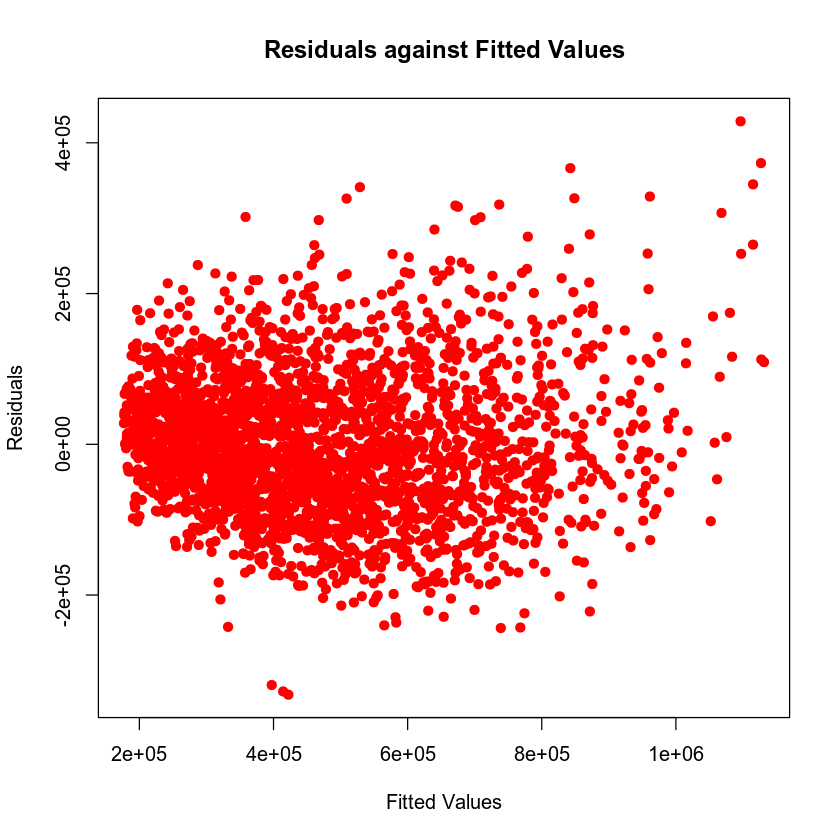

```r
plot(fitted_values, residuals,
     main = "Residuals against Fitted Values",
     xlab = "Fitted Values", ylab = "Residuals",
     col="red",
     pch = 19)
```

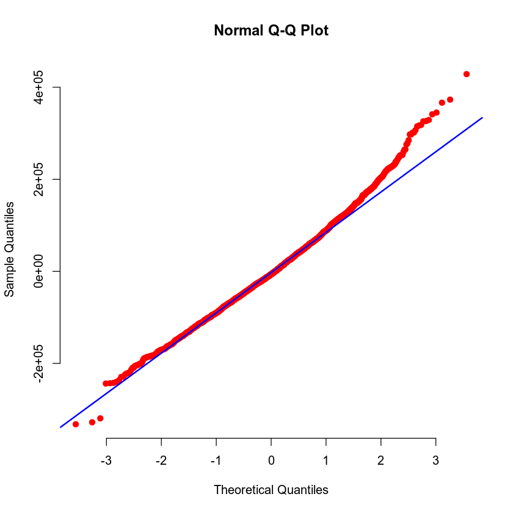

```r
qqnorm(residuals, pch = 19, col="red", frame = FALSE)
qqline(residuals, col = "blue", lwd = 2)
```

```r
newdata <- data.frame(appliance_age=1, crime=81.01)

print("prediction interval")
prediction_pred_int <- predict(higher_model, newdata, interval="predict", level=0.90)
round(prediction_pred_int, 4)

print("confidence interval")
prediction_conf_int <- predict(higher_model, newdata, interval="confidence", level=0.90)
round(prediction_conf_int, 4)
```

```
[1] "prediction interval"
```

A matrix: 1 × 3 of type dbl

| fit | lwr | upr |
| --- | --- | --- |
| 864449.7 | 711593 | 1017306 |

```
[1] "confidence interval"
```

A matrix: 1 × 3 of type dbl

| fit | lwr | upr |
| --- | --- | --- |
| 864449.7 | 854136 | 874763.3 |

```r
newdata <- data.frame(appliance_age=15, crime=200.5)

print("prediction interval")
prediction_pred_int <- predict(higher_model, newdata, interval="predict", level=0.90)
round(prediction_pred_int, 4)

print("confidence interval")
prediction_conf_int <- predict(higher_model, newdata, interval="confidence", level=0.90)
round(prediction_conf_int, 4)
```

```
[1] "prediction interval"
```

A matrix: 1 × 3 of type dbl

| fit | lwr | upr |
| --- | --- | --- |
| 271051.6 | 118454.4 | 423648.8 |

```
[1] "confidence interval"
```

A matrix: 1 × 3 of type dbl

| fit | lwr | upr |
| --- | --- | --- |
| 271051.6 | 265846 | 276257.2 |

# Nested Models F-Test

You have been asked to create a reduced model and compare it with the complete second order model (Model #2 above). Before writing any code, review Section 5 of the Summary Report template to see the questions you will need to answer.

Run your scripts to get the outputs of your regression analysis. Then use the outputs to answer the questions in your summary report.

**Note: Use the + (plus) button to add new code blocks, if needed.**

```r
nested_model <- lm(price ~ appliance_age + crime + appliance_age:crime, data=housing)
summary(nested_model1)
```

[output not shown]

```r
complete_model <- lm(price ~ appliance_age + crime + appliance_age:crime + I(appliance_age^2) + I(crime^2), data=housing)
summary(complete_model)
```

```
Call:
lm(formula = price ~ appliance_age + crime + appliance_age:crime +
    I(appliance_age^2) + I(crime^2), data = housing)

Residuals:
    Min      1Q  Median      3Q     Max
-340502  -61196   -6241   57054  427449

Coefficients:
                      Estimate Std. Error t value Pr(>|t|)
(Intercept)          1.161e+06  9.116e+03 127.376   <2e-16 ***
appliance_age       -4.256e+04  1.375e+03 -30.951   <2e-16 ***
crime               -3.678e+03  1.481e+02 -24.827   <2e-16 ***
I(appliance_age^2)   8.330e+02  7.933e+01  10.501   <2e-16 ***
I(crime^2)           6.380e+00  7.265e-01   8.782   <2e-16 ***
appliance_age:crime  1.390e+01  1.298e+01   1.072    0.284
---
Signif. codes:  0 '***' 0.001 '**' 0.01 '*' 0.05 '.' 0.1 ' ' 1

Residual standard error: 92690 on 2686 degrees of freedom
Multiple R-squared:  0.8088,	Adjusted R-squared:  0.8084
F-statistic:  2272 on 5 and 2686 DF,  p-value: < 2.2e-16
```

```r
nested_model <- lm(price ~ appliance_age + crime + appliance_age:crime, data=housing)
complete_model <- lm(price ~ appliance_age + crime + appliance_age:crime + I(appliance_age^2) + I(crime^2), data=housing)
anova(nested_model, complete_model)
```

A anova: 2 × 6

| Res.Df <dbl> | RSS <dbl> | Df <dbl> | Sum of Sq <dbl> | F <dbl> | Pr(>F) <dbl> |
| --- | --- | --- | --- | --- | --- |
| 2688 | 2.419614e+13 | NA | NA | NA | NA |
| 2686 | 2.307487e+13 | 2 | 1.121271e+12 | 65.26001 | 2.113594e-28 |

```r
housing
```

A data.frame: 2692 × 22

| id <int> | price <int> | bedrooms <int> | bathrooms <dbl> | sqft_living <int> | sqft_lot <int> | floors <dbl> | backyard <fct> | view <fct> | condition <int> | ⋯ | sqft_basement <int> | yr_built <int> | yr_renovated <int> | renovated <int> | zipcode <int> | sqft_living15 <int> | sqft_lot15 <int> | age <int> | appliance_age <dbl> | crime <int> |
| --- | --- | --- | --- | --- | --- | --- | --- | --- | --- | --- | --- | --- | --- | --- | --- | --- | --- | --- | --- | --- |
| 1 | 325000 | 3 | 2.25 | 1570 | 43350 | 1.0 | 0 | 2 | 4 | ⋯ | 0 | 1967 | 0 | 0 | 98022 | 1570 | 220849 | 48 | 17.7 | 138 |
| 2 | 745000 | 5 | 3.00 | 2400 | 10126 | 2.0 | 0 | 2 | 3 | ⋯ | 0 | 1981 | 0 | 0 | 98126 | 2250 | 3946 | 34 | 3.2 | 101 |
| 3 | 571000 | 4 | 1.00 | 1350 | 4000 | 1.5 | 0 | 0 | 3 | ⋯ | 0 | 1930 | 0 | 0 | 98117 | 1520 | 4000 | 85 | 7.6 | 110 |
| 4 | 395000 | 2 | 2.00 | 1960 | 4018 | 1.0 | 0 | 0 | 5 | ⋯ | 980 | 1950 | 0 | 0 | 98108 | 1240 | 4641 | 65 | 13.0 | 118 |
| 5 | 449950 | 3 | 1.75 | 1470 | 7590 | 1.0 | 0 | 0 | 3 | ⋯ | 0 | 1988 | 0 | 0 | 98117 | 1700 | 5080 | 27 | 6.8 | 98 |
| 6 | 243000 | 3 | 1.75 | 1450 | 12125 | 1.0 | 0 | 0 | 4 | ⋯ | 0 | 1981 | 0 | 0 | 98001 | 1210 | 12125 | 34 | 14.1 | 209 |
| 7 | 219950 | 3 | 1.50 | 1070 | 6601 | 1.0 | 0 | 0 | 3 | ⋯ | 0 | 1985 | 0 | 0 | 98002 | 1030 | 6614 | 30 | 14.4 | 171 |
| 8 | 799000 | 5 | 2.75 | 2500 | 19783 | 1.0 | 1 | 2 | 4 | ⋯ | 0 | 1959 | 0 | 0 | 98005 | 1700 | 15375 | 56 | 5.1 | 96 |
| 9 | 207000 | 4 | 2.00 | 1690 | 7728 | 1.5 | 0 | 0 | 4 | ⋯ | 0 | 1967 | 0 | 0 | 98198 | 1480 | 8009 | 48 | 22.5 | 188 |
| 10 | 750000 | 4 | 2.75 | 2640 | 3750 | 2.0 | 0 | 0 | 5 | ⋯ | 800 | 1911 | 0 | 1 | 98117 | 1690 | 5000 | 104 | 5.8 | 40 |
| 11 | 350000 | 5 | 1.75 | 2330 | 14322 | 1.0 | 0 | 0 | 4 | ⋯ | 1150 | 1968 | 0 | 0 | 98059 | 1690 | 10010 | 47 | 14.9 | 162 |
| 12 | 272000 | 3 | 2.00 | 1380 | 7476 | 1.0 | 0 | 0 | 3 | ⋯ | 0 | 1989 | 0 | 0 | 98001 | 1600 | 7227 | 26 | 13.4 | 159 |
| 13 | 384950 | 4 | 2.50 | 2380 | 4913 | 2.0 | 0 | 0 | 3 | ⋯ | 0 | 2006 | 0 | 0 | 98038 | 2580 | 5311 | 9 | 10.3 | 157 |
| 14 | 272000 | 4 | 2.75 | 1810 | 7350 | 1.0 | 0 | 0 | 4 | ⋯ | 610 | 1980 | 0 | 0 | 98030 | 1750 | 7350 | 35 | 17.3 | 248 |
| 15 | 278000 | 5 | 1.50 | 1820 | 8712 | 1.0 | 0 | 0 | 5 | ⋯ | 730 | 1960 | 0 | 0 | 98032 | 1820 | 8712 | 55 | 10.0 | 193 |
| 16 | 540000 | 6 | 3.00 | 2870 | 206474 | 2.0 | 0 | 0 | 3 | ⋯ | 540 | 1960 | 1985 | 1 | 98042 | 2380 | 59677 | 55 | 12.9 | 100 |
| 17 | 755000 | 3 | 2.50 | 2420 | 8856 | 1.0 | 0 | 2 | 3 | ⋯ | 800 | 1957 | 0 | 0 | 98118 | 2650 | 9750 | 58 | 3.5 | 134 |
| 18 | 918000 | 5 | 3.50 | 3920 | 5150 | 2.0 | 0 | 2 | 3 | ⋯ | 1100 | 2004 | 0 | 1 | 98052 | 3170 | 5530 | 11 | 6.9 | 32 |
| 19 | 411000 | 1 | 1.00 | 1080 | 5000 | 1.5 | 0 | 0 | 3 | ⋯ | 0 | 1948 | 0 | 0 | 98199 | 1620 | 4000 | 67 | 10.1 | 149 |
| 20 | 275000 | 2 | 2.00 | 1290 | 9041 | 1.0 | 0 | 0 | 3 | ⋯ | 340 | 1956 | 0 | 0 | 98108 | 1290 | 5000 | 59 | 19.0 | 119 |
| 21 | 455000 | 3 | 1.50 | 1380 | 6657 | 2.0 | 0 | 0 | 3 | ⋯ | 0 | 1986 | 0 | 0 | 98034 | 1420 | 8187 | 29 | 10.6 | 162 |
| 22 | 339000 | 4 | 2.50 | 2840 | 8746 | 2.0 | 0 | 0 | 3 | ⋯ | 0 | 2001 | 0 | 0 | 98022 | 2630 | 9900 | 14 | 13.3 | 243 |
| 23 | 445000 | 3 | 1.75 | 1850 | 7056 | 2.5 | 0 | 0 | 4 | ⋯ | 0 | 1979 | 0 | 0 | 98052 | 1970 | 7056 | 36 | 7.0 | 177 |
| 24 | 285950 | 2 | 1.00 | 710 | 7120 | 1.0 | 0 | 0 | 5 | ⋯ | 0 | 1942 | 0 | 0 | 98146 | 1100 | 7020 | 73 | 11.3 | 109 |
| 25 | 790000 | 4 | 3.00 | 3180 | 12070 | 2.0 | 0 | 0 | 4 | ⋯ | 0 | 1976 | 0 | 0 | 98074 | 3110 | 12600 | 39 | 5.7 | 48 |
| 26 | 310000 | 2 | 1.00 | 1400 | 4500 | 1.0 | 0 | 0 | 3 | ⋯ | 500 | 1922 | 0 | 0 | 98055 | 1400 | 5500 | 93 | 14.2 | 143 |
| 27 | 529950 | 2 | 2.50 | 1500 | 1174 | 2.0 | 0 | 0 | 3 | ⋯ | 360 | 2014 | 0 | 0 | 98107 | 1550 | 1519 | 1 | 9.3 | 85 |
| 28 | 339000 | 3 | 1.50 | 1740 | 21980 | 1.0 | 0 | 0 | 4 | ⋯ | 0 | 1973 | 0 | 0 | 98042 | 1400 | 16100 | 42 | 8.9 | 125 |
| 29 | 790000 | 4 | 2.50 | 3500 | 9198 | 2.0 | 0 | 0 | 3 | ⋯ | 0 | 2004 | 0 | 0 | 98053 | 3990 | 8598 | 11 | 2.3 | 69 |
| 30 | 595000 | 4 | 1.50 | 1350 | 8113 | 1.0 | 0 | 0 | 4 | ⋯ | 0 | 1959 | 0 | 0 | 98004 | 1930 | 8113 | 56 | 11.2 | 92 |
| ⋮ | ⋮ | ⋮ | ⋮ | ⋮ | ⋮ | ⋮ | ⋮ | ⋮ | ⋮ | ⋱ | ⋮ | ⋮ | ⋮ | ⋮ | ⋮ | ⋮ | ⋮ | ⋮ | ⋮ | ⋮ |
| 2663 | 695000 | 4 | 2.50 | 2830 | 14538 | 2.0 | 0 | 0 | 3 | ⋯ | 0 | 2003 | 0 | 0 | 98065 | 2270 | 6939 | 12 | 8.5 | 80 |
| 2664 | 250000 | 3 | 1.00 | 1060 | 52272 | 1.0 | 0 | 0 | 3 | ⋯ | 0 | 1960 | 0 | 0 | 98030 | 1900 | 5971 | 55 | 18.6 | 200 |
| 2665 | 405000 | 3 | 1.75 | 1260 | 7373 | 1.0 | 0 | 0 | 4 | ⋯ | 0 | 1979 | 0 | 0 | 98034 | 1360 | 7373 | 36 | 10.1 | 107 |
| 2666 | 673000 | 4 | 2.25 | 2590 | 8190 | 2.0 | 0 | 0 | 4 | ⋯ | 0 | 1980 | 0 | 0 | 98006 | 2260 | 8335 | 35 | 6.1 | 96 |
| 2667 | 595000 | 4 | 2.50 | 2100 | 3125 | 2.0 | 0 | 1 | 3 | ⋯ | 700 | 1907 | 1993 | 1 | 98107 | 2060 | 5040 | 108 | 6.5 | 110 |
| 2668 | 237000 | 3 | 2.00 | 1710 | 7920 | 1.0 | 0 | 0 | 3 | ⋯ | 450 | 1968 | 0 | 0 | 98003 | 1760 | 8120 | 47 | 21.9 | 135 |
| 2669 | 225000 | 4 | 2.00 | 1750 | 7245 | 1.0 | 0 | 0 | 4 | ⋯ | 700 | 1974 | 0 | 0 | 98092 | 1640 | 7245 | 41 | 13.4 | 138 |
| 2670 | 525000 | 4 | 2.75 | 2440 | 5080 | 2.0 | 0 | 0 | 3 | ⋯ | 690 | 1960 | 0 | 0 | 98126 | 1920 | 6375 | 55 | 12.6 | 70 |
| 2671 | 355000 | 4 | 2.50 | 2150 | 3600 | 2.0 | 0 | 0 | 3 | ⋯ | 0 | 2010 | 0 | 0 | 98038 | 2220 | 3915 | 5 | 12.2 | 174 |
| 2672 | 490000 | 2 | 1.00 | 1760 | 5250 | 1.0 | 0 | 1 | 4 | ⋯ | 760 | 1951 | 0 | 0 | 98126 | 1760 | 5400 | 64 | 8.1 | 131 |
| 2673 | 269000 | 3 | 2.50 | 1440 | 3800 | 2.0 | 0 | 0 | 3 | ⋯ | 0 | 2005 | 0 | 0 | 98038 | 1890 | 3819 | 10 | 14.1 | 123 |
| 2674 | 363000 | 4 | 2.50 | 2180 | 9281 | 2.0 | 0 | 0 | 3 | ⋯ | 0 | 2004 | 0 | 0 | 98042 | 2520 | 9520 | 11 | 9.8 | 105 |
| 2675 | 380000 | 2 | 1.00 | 1000 | 4800 | 1.0 | 0 | 0 | 3 | ⋯ | 0 | 1952 | 0 | 0 | 98117 | 1000 | 4800 | 63 | 9.7 | 161 |
| 2676 | 926500 | 4 | 2.75 | 2900 | 17802 | 1.0 | 1 | 1 | 3 | ⋯ | 1150 | 1981 | 0 | 0 | 98034 | 2900 | 15720 | 34 | 2.5 | 33 |
| 2677 | 550000 | 4 | 3.50 | 2770 | 24140 | 2.0 | 0 | 0 | 3 | ⋯ | 0 | 1967 | 0 | 0 | 98033 | 1720 | 16011 | 48 | 4.8 | 132 |
| 2678 | 397500 | 3 | 2.00 | 1510 | 6710 | 1.0 | 0 | 0 | 3 | ⋯ | 440 | 1972 | 0 | 0 | 98034 | 1660 | 6600 | 43 | 11.0 | 144 |
| 2679 | 529100 | 2 | 1.00 | 1290 | 6528 | 1.5 | 0 | 0 | 4 | ⋯ | 0 | 1941 | 0 | 0 | 98115 | 1670 | 5712 | 74 | 11.7 | 102 |
| 2680 | 415500 | 3 | 1.50 | 1240 | 12400 | 1.0 | 0 | 0 | 3 | ⋯ | 0 | 1958 | 0 | 0 | 98007 | 1640 | 9600 | 57 | 12.0 | 117 |
| 2681 | 340000 | 4 | 2.50 | 2690 | 6099 | 2.0 | 0 | 0 | 3 | ⋯ | 0 | 1998 | 0 | 0 | 98092 | 2520 | 6168 | 17 | 15.8 | 135 |
| 2682 | 991700 | 4 | 3.00 | 2290 | 2350 | 2.0 | 0 | 2 | 3 | ⋯ | 680 | 1924 | 2011 | 1 | 98116 | 1610 | 3820 | 91 | 1.3 | 47 |
| 2683 | 545000 | 4 | 2.00 | 1700 | 2350 | 1.0 | 0 | 0 | 3 | ⋯ | 850 | 1926 | 2014 | 1 | 98117 | 1600 | 4160 | 89 | 9.9 | 89 |
| 2684 | 476000 | 3 | 1.75 | 1650 | 9600 | 1.0 | 0 | 0 | 4 | ⋯ | 0 | 1977 | 0 | 0 | 98075 | 2040 | 12220 | 38 | 7.7 | 156 |
| 2685 | 567500 | 3 | 2.50 | 3090 | 67082 | 2.0 | 0 | 0 | 3 | ⋯ | 0 | 1990 | 0 | 0 | 98038 | 3650 | 62290 | 25 | 7.0 | 118 |
| 2686 | 249900 | 3 | 2.50 | 1630 | 7700 | 1.0 | 0 | 0 | 3 | ⋯ | 510 | 1978 | 0 | 0 | 98031 | 1640 | 8160 | 37 | 11.2 | 258 |
| 2687 | 378500 | 4 | 2.00 | 1830 | 6000 | 1.0 | 0 | 0 | 5 | ⋯ | 760 | 1953 | 0 | 0 | 98118 | 1830 | 5500 | 62 | 9.7 | 213 |
| 2688 | 680000 | 4 | 2.75 | 2330 | 3920 | 2.0 | 0 | 0 | 3 | ⋯ | 0 | 2005 | 0 | 0 | 98029 | 2410 | 4063 | 10 | 7.0 | 91 |
| 2689 | 630000 | 4 | 2.50 | 2240 | 4025 | 1.0 | 0 | 1 | 3 | ⋯ | 990 | 1926 | 2005 | 1 | 98115 | 1380 | 3500 | 89 | 3.7 | 83 |
| 2690 | 560000 | 3 | 2.75 | 1620 | 7500 | 1.0 | 0 | 0 | 5 | ⋯ | 480 | 1979 | 0 | 0 | 98074 | 1900 | 7500 | 36 | 6.5 | 125 |
| 2691 | 649950 | 3 | 2.50 | 2150 | 15304 | 2.0 | 0 | 0 | 4 | ⋯ | 0 | 1979 | 0 | 0 | 98006 | 2540 | 10507 | 36 | 13.7 | 79 |
| 2692 | 675000 | 3 | 1.50 | 2510 | 3600 | 2.5 | 0 | 0 | 4 | ⋯ | 0 | 1907 | 0 | 0 | 98112 | 1740 | 1885 | 108 | 8.4 | 92 |

## End of Project One Jupyter Notebook

The HTML output can be downloaded by clicking **File**, then **Download as**, then **HTML**. Be sure to answer all of the questions in the Summary Report template for Project One, and to include your completed Jupyter Notebook scripts as part of your submission.